BIO144 · FS 2027 · Week 1

# Introduction and a live data analysis

Data Analysis in Biology

Prof. Owen Petchey · University of Zurich

[figure not shown]

Monday 22 February 2027 · 13:00–14:45

## Today

13:00Why data analysis, and what makes it good

13:15How the course works, and the exam

13:35How we will work together

13:40AI assistants

13:50RStudio Server

13:55You collect some data

14:00Short break

14:10Live data analysis, from question to answer

14:40What you should already know · this week

## Why should you care about data analysis?

Think · Pair · Share

Only you can answer that. Purpose comes from doing something **meaningful to you** and **useful to others**.

**Show that a problem exists**Good analysis makes invisible problems visible, and helps others take them seriously.

**Test solutions**Does an intervention work? For everyone? With unintended consequences?

**Evaluate evidence that affects lives**Whether a drug works, or has serious side effects, shapes real decisions.

**Question powerful claims**Marketing, policy and messaging often rely on selective statistics. What's missing? What's exaggerated?

**Protect others**Especially those with less power: from children targeted by unhealthy products to communities facing environmental harm.

**Serve something bigger**Science, public trust, health, biodiversity, fairness.

## Questions you'll work on

Tap a card to see the question

## Every time, the same pattern

**Question**or puzzle, or problem

**Data + analysis**collected and done well

**Answer**or solution

But how do we make sure the analysis is a good one?

High-quality data analysis

## Four principles for reliable findings

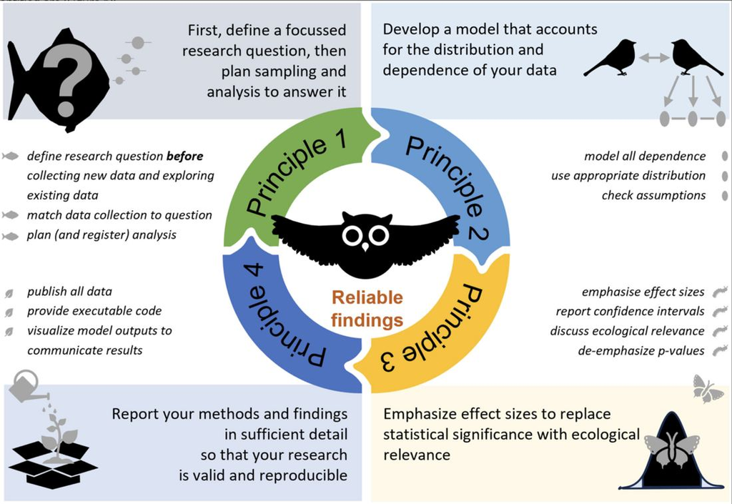

Popovic, G. et al. (2024). Four principles for improved statistical ecology. *Methods in Ecology and Evolution*, 15, 266–281.

The paper

How the course is organised

## Every week has four parts

Mon

**Lecture**13:00–14:45

Tue

**Homework**before the practical

Wed

**Homework**when it suits you

Thu

**Practical A**13:00–15:00

Fri

**Practical B**13:00–15:00

**Weekly practice quiz** · any time, as often as you likenot marked

Your practical is on Thursday *or* Friday. Swapping for a week or two is fine without asking.

## The semester at a glance

Tap a week

Unit (new content)Self-study week, open practicalsSpring breakFinal examSomething to note

The conceptual side

## Lectures, apart from today

- **No slides.**
- The **course book** contains what you need to know: one chapter per week.
- I talk, draw, and ask you questions. Little or no live coding: the code is in each chapter's walkthrough script.
- You don't need to prepare. If you'd like to:  
  none · a little (skim the chapter) · more (read it, try the code)

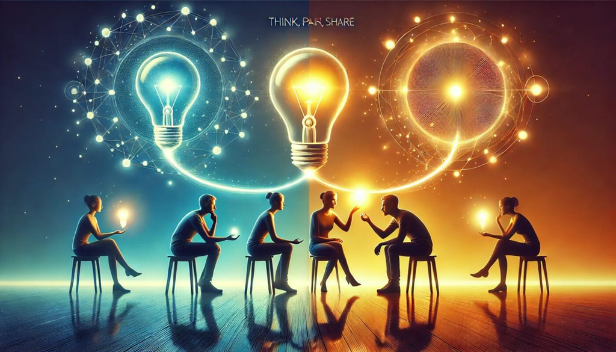

Think · Pair · Share

## Talking to a neighbour helps, even when neither of you knew

**Q1** answer alone · **Q1ad** same question after discussion · **Q2** a new, similar question, alone

Smith, M.K. et al. (2009). Why peer discussion improves student performance on in-class concept questions. *Science*, 323, 122–124. Values read from their Fig. 1 (approximate).

## The team

You

Lectures

Practicals

Forum on OLAT

Email

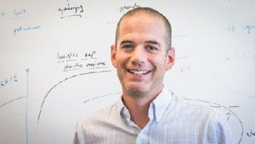

**Prof. Owen Petchey**Lecturer

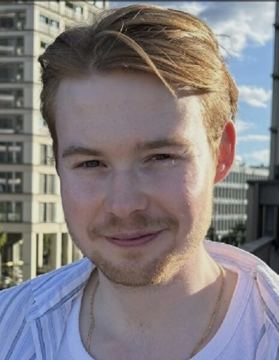

**Til Hämmig**Head teaching assistant; guest lectures in Units 8 and 9

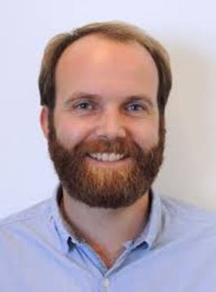

**Dr Frank Pennekamp**Examinations

TAs

**Numerous teaching assistants**In every practical

## Everything is on four websites

The hub

### OLAT

Links to everything else, and the **discussion forum**: ask questions and make requests there.

How it works

### Course information

General information, learning objectives, the schedule, and a page for each week.

[opetchey.github.io/BIO144_Course_Information](https://opetchey.github.io/BIO144_Course_Information/)

What to know

### Course book

One chapter per week. Together with the learning objectives, it defines what you need for the exam.

[opetchey.github.io/BIO144_Course_Book](https://opetchey.github.io/BIO144_Course_Book/)

What to do

### Homework, practicals, quizzes

One page per week, on the UZH RStudio Connect server. Off campus, connect to the **UZH VPN** first.

Linked from each week's page

Course information

Much of the material is new or newly revised. If something is unclear, too brief or wrong, please tell us.

## Getting help

### Practicals

Thursday and Friday: ask a TA, or your neighbour.

### OLAT forum

Any time. We aim to answer within **two days**. Anonymous posts are possible.

### Lectures

During and after.

### Email

Fine, though I may ask you to post on the forum so everyone benefits.

Tough statistical questions: post them on the forum. Prof. Furrer has kindly agreed to help with those I can't answer.

The last day we can guarantee help with content: the last practical of the semester (Fri 4 June).

From the 2026 course evaluation

## You told us, so in 2027…

| You told us (2026) | What we did for 2027 |
| --- | --- |
| Interactive lectures, examples and the forum were appreciated. Practicals, quizzes, TAs and the course book help a lot. | We kept all of that. |
| Live coding in lectures was too fast to follow or copy, and the code wasn't available afterwards. | Little or no live coding in lectures. Every chapter has a code walkthrough script, with a “Practical toolbox”, to work through at your own pace. |
| Please give us solutions, or a way to check our work. | An example solution script for every practical (last tab). All quiz answers re-checked. |
| R is hard for beginners, and Week 1 was too hard. | Unit 1 practical rebuilt: log in, make a project, import your data, fix a script. “Getting R & RStudio” in the self-tests. |
| Three websites were confusing, and it wasn't clear how much of the book mattered. | Every Unit page has the same layout and its learning objectives: those plus the chapter define the exam. One page lists all homework, practicals and quizzes. |
| Holidays meant the Friday group lost practicals. | Every holiday swap is in the schedule. Two self-study weeks with open practical sessions. |
| “Prof. Petchey talks for hours on end.” | Sit back, open popcorn, enjoy :) |

## The final examination

Friday18 June 202710:00–12:00 · Irchel Resit: Thursday 26 August 2027, 14:15–16:15  
Mandatory Probeprüfung in mid to late May

1**Case studies:** you analyse datasets in R and answer questions about them.

40About 40 questions: single choice, multiple choice or **numeric** (default 2 decimal places).

A4**Three sheets** of A4 notes, both sides. One translation dictionary.

⌨Your laptop and **RStudio Server**. How the exam setup works will be announced by late May.

∅**No AI** of any kind, including Copilot. Prohibited materials and tools are strictly controlled.

✓A **mock exam** on OLAT, and the weekly quizzes, give you practice.

**Best preparation:** do analyses yourself, every week. Be quick at importing data.

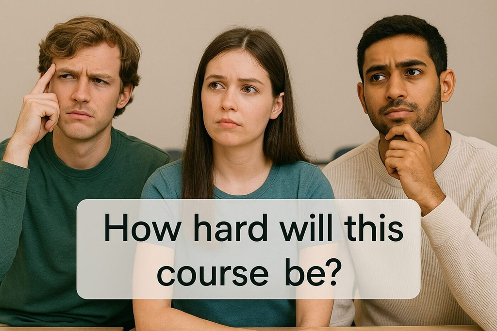

Think · Pair · Share

## How hard will this course be?

**4 credit points ≈ 120 hours**

⅓ in class

⅔ self-study

Weeks are not all the same amount of work: look ahead and plan early.

Keep up, and reach out early if you feel you're falling behind.

My role, your role, and how we'll work together

## Becoming great data analysts

- Everyone here can learn to think analytically and statistically.
- I'll hold you to **high standards**, because I believe you can meet them. My job is to support you in reaching them.
- **Struggle is part of growth**, not a sign of failure.
- Stress before a challenge is normal: a faster heart and breathing are your body giving you more resources.

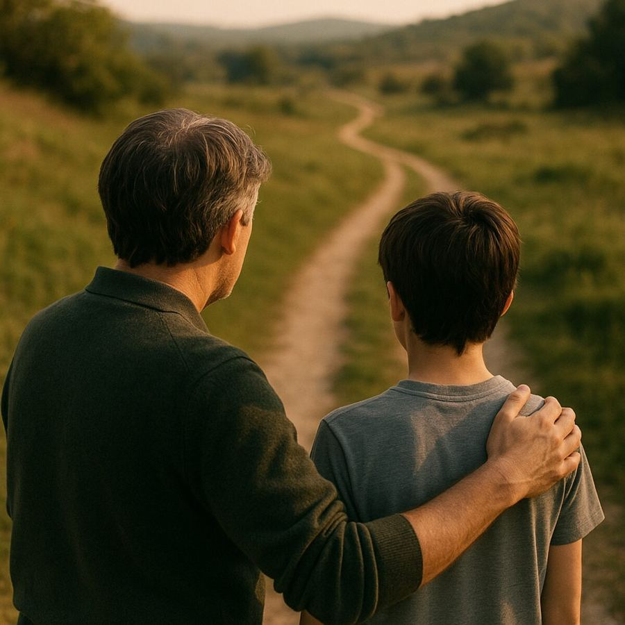

When did someone believe in you more than you believed in yourself? What happened?

## High standards and wise feedback

“I'm giving you these comments because I have high standards and I know that you can meet them.”

“Wise feedback”: Cohen, G.L., Steele, C.M. & Ross, L.D. (1999). *Personality and Social Psychology Bulletin*, 25, 1302–1318.

- Feedback will be honest and specific.
- It comes from belief in your potential, not criticism of you as a person.
- If it feels like criticism, try to reframe it as being challenged to grow.

**This class is a safe space for you, and a challenging space for you.**

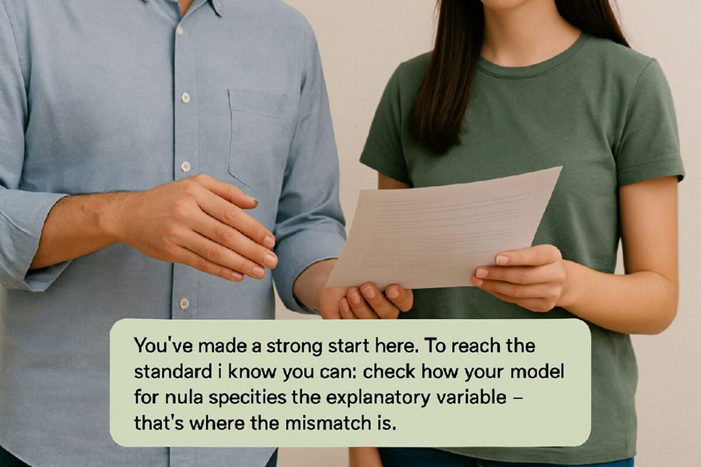

Klicker

Think · Pair · Share

How comfortable are you receiving critical feedback?

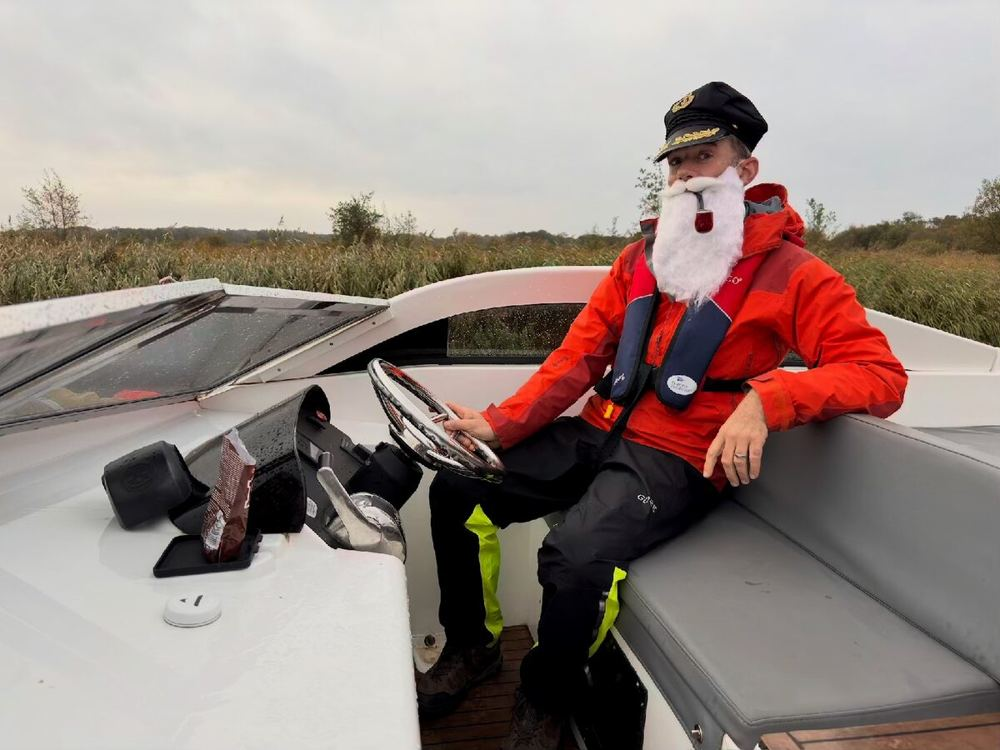

## I may be a professor, but I'm also human

Call me **Professor Petchey** or **Owen**, whatever you're comfortable with.

(Probably not “dude” or “mate”.)

We are here to support you: to give you the knowledge of how to learn more, and the confidence that you can.

AI assistants

## Helpful, or harmful to your learning?

Vote, then tap

## Your relationship with AI assistants

### A strong relationship

The AI is a knowledgeable collaborator that complements your skills and supports your growth. **You** provide context, direction and critical judgement.

### A poor relationship

You use output you don't understand, copying and pasting. Errors slip through, and your own skills stagnate.

The knowledge *you* bring is what makes the relationship good. So: **minimise your use of AI during the course** (and of the example solutions). Do the work, get the benefit.

In the exam, prohibited tools are strictly controlled: **no generative AI at all**, and no Copilot in RStudio. Practise without it.

Think · Pair · Share

## What can I use an AI assistant for in BIO144?

And what should I not use it for?

Klicker

## RStudio Server

RStudio in your web browser: [rstudio.mnf.uzh.ch](https://rstudio.mnf.uzh.ch/), with your UZH login.

- **You must use it in the exam**, so make sure you can log in and work there.
- Good: most of the setup is done for you.
- Less good: you need an internet connection.
- Everyone in the OLAT course is registered. Not in OLAT? No access.
- Prefer your own laptop? Fine: see “Getting R & RStudio” in the Previous Knowledge self-tests.

The Unit 1 practical starts by logging in.

[figure not shown]

rstudio.mnf.uzh.ch

We need some data

## Your turn: measure your reaction time

1Open the **reaction time test** (humanbenchmark.com).

2Do it **five times**. Note each time, in **milliseconds**.

3Enter your five times, and answer the other questions, in the **form**.

It's anonymous. After the lecture the class data are published as reaction_times_2027.csv, for the practical.

Reaction time test

Data form

Both links are on the course information site, Unit 1 page, “Lecture”.

## Short break

10:00

Live data analysis

# From question to answer in under an hour

- It's a demonstration: a feel for what's involved.
- You'll understand some of it, and not other parts. That's expected.
- **Keep notes about what you don't understand.** Look for the answers as the course goes on.

## The workflow in twelve steps

The first six steps all happen **before** any data are collected. That's Principle 1 in action.

## What should our question be?

- Of interest to us, and of some importance.
- Answerable with data we can collect, within our constraints.

Do the reaction times of male and female students at the University of Zurich differ?

“Male” and “female”: sex assigned at birth. Why care? Reaction times matter for safety (driving) and in sport (the start of a sprint).

## Expectation

There has been quite a lot of research already.

In general, males tend to have faster reaction times than females. So we expect the same for students at UZH.

Curious? Lipps et al. (2011) looked at reaction times of sprinters at the Beijing Olympics (PLOS ONE).

## What graph will answer the question?

Simulated data · not our data

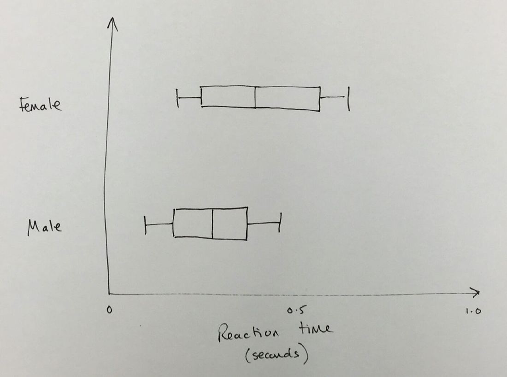

## What statistical test? What assumptions?

Response: reaction time (continuous). Explanatory variable: sex (two groups).

**A two-sample t-test** compares the means of two groups.

A natural first choice here. In later weeks you'll see it is a special case of a linear model.

**Its assumptions?** (tap)

Independent observations · values roughly normally distributed in each group · similar variances in the two groups.

## Selection of subjects

Ideally a random sample of the population we want to draw conclusions about.

Are you a random sample of… (tap)

How subjects are selected limits who our conclusions apply to.

## Collecting data, and ethics

How? An online test, and a form. **Done: you just did it.**

Because these are data about people, we should think about ethics:

### Consent

Taking part was voluntary.

### Anonymity

No names. Could anyone be identified?

### Use and sharing

For teaching, published for the practical.

## Data wrangling, visualisation, test

Live in RStudio →

Why a script in R, rather than pointing and clicking? It makes the analysis:

EfficientConsistentRepeatableReliableReadableRobustPersistentSharableScalable

That's Principle 4 in action.

## Critical thinking, and reporting

### How big is the difference?

Is it biologically relevant? (Principle 3)

### How precise?

The confidence interval of the difference.

### Other explanations?

Could something other than sex explain it?

### To whom does it apply?

Given how the subjects were selected.

**Report:** a clear figure, and a sentence with the estimate, its uncertainty, and the test.

## The four principles, in today's analysis

Principle 1

### Question first

Question, expectation, graph and test, all decided before collecting data.

Principle 2

### A suitable model

The t-test's assumptions. Later: counts, binary data, repeated measures.

Principle 3

### Effect sizes

How big is the difference, how precise, does it matter?

Principle 4

### Reproducible

A script anyone can re-run, on data that are shared.

Activate your prior learning

## What it helps to know already

0 of 0

#### Summarising data

#### Types of variable

#### Statistical ideas

#### Probability

#### Methods and graphs

#### Notation

x = (1/n) Σ x<sub>i</sub>s² = 1/(n−1) Σ (x<sub>i</sub> − x)²More in Chapter 1 of the course book

Previous Knowledge self-tests (UZH network or VPN). Not sure about some? That's what they are for.

## This week

Before the practical

### Homework

Read Chapter 1 of the course book. Work through the Unit 1 homework.

Thu 25 or Fri 26 Feb

### Practical

Log in to RStudio Server, make a project, import *your* data, fix a broken script.

Any time

### Weekly quiz

Check your understanding. Not marked.

If needed

### Previous knowledge

The self-tests, and help with installing R and RStudio.

Unit 1 page

See you in the practical. Have fun!

Questions any time: the OLAT forum.

BIO144 · Week 1 · Introduction

### All slides